# Manifold Learning with Isomap

∿Numerical Tours

# Manifold Learning with Isomap

Recover a low-dimensional representation of a curved point cloud using neighborhood-graph distances. Compare geodesic and Euclidean distances, then use a spectral embedding to reveal the manifold’s intrinsic geometry.

## Run this tour

Run the cells in order with a Python 3 kernel. The first cell locates the companion data and toolbox and installs missing dependencies when needed. All worked examples include their implementation directly in this notebook. Random seeds make comparisons reproducible; you can change them to explore other samples.

```python
# Locate the companion toolbox locally, or fetch it for a standalone/Colab copy.
from pathlib import Path
import importlib.util
import os
import subprocess
import sys

working = Path.cwd()
candidates = [working, working / "python", working.parent / "python"]
python_dir = next((p for p in candidates if (p / "nt_toolbox").is_dir()), None)
if python_dir is None:
    checkout = working / "numerical-tours-support"
    if not checkout.exists():
        subprocess.run(
            [
                "git",
                "clone",
                "--depth",
                "1",
                "--branch",
                "master",
                "https://github.com/gpeyre/numerical-tours.git",
                str(checkout),
            ],
            check=True,
        )
    python_dir = checkout / "python"
os.chdir(python_dir)
if str(python_dir) not in sys.path:
    sys.path.insert(0, str(python_dir))
requirements = python_dir / "requirements.txt"
if any(
    importlib.util.find_spec(name) is None
    for name in [
        "numpy",
        "scipy",
        "matplotlib",
        "skimage",
        "sklearn",
        "pywt",
        "ipywidgets",
        "cvxpy",
        "skfmm",
        "autograd",
        "progressbar",
        "celer",
    ]
):
    subprocess.run(
        [sys.executable, "-m", "pip", "install", "-r", str(requirements)], check=True
    )

import numpy as np
import matplotlib.pyplot as plt

np.random.seed(0)
plt.rcParams.update(
    {
        "figure.figsize": (8, 4),
        "figure.dpi": 100,
        "axes.spines.top": False,
        "axes.spines.right": False,
        "font.size": 11,
        "image.cmap": "gray",
    }
)
%matplotlib inline
```

$\newcommand{\dotp}[2]{\langle #1, #2 \rangle}$ $\newcommand{\enscond}[2]{\lbrace #1, #2 \rbrace}$ $\newcommand{\pd}[2]{ \frac{ \partial #1}{\partial #2} }$ $\newcommand{\umin}[1]{\underset{#1}{\min}\;}$ $\newcommand{\umax}[1]{\underset{#1}{\max}\;}$ $\newcommand{\uargmin}[1]{\underset{#1}{argmin}\;}$ $\newcommand{\norm}[1]{\|#1\|}$ $\newcommand{\abs}[1]{\left|#1\right|}$ $\newcommand{\choice}[1]{ \left\{ \begin{array}{l} #1 \end{array} \right. }$ $\newcommand{\pa}[1]{\left(#1\right)}$ $\newcommand{\diag}[1]{{diag}\left( #1 \right)}$ $\newcommand{\qandq}{\quad\text{and}\quad}$ $\newcommand{\qwhereq}{\quad\text{where}\quad}$ $\newcommand{\qifq}{ \quad \text{if} \quad }$ $\newcommand{\qarrq}{ \quad \Longrightarrow \quad }$ $\newcommand{\ZZ}{\mathbb{Z}}$ $\newcommand{\CC}{\mathbb{C}}$ $\newcommand{\RR}{\mathbb{R}}$ $\newcommand{\EE}{\mathbb{E}}$ $\newcommand{\Zz}{\mathcal{Z}}$ $\newcommand{\Ww}{\mathcal{W}}$ $\newcommand{\Vv}{\mathcal{V}}$ $\newcommand{\Nn}{\mathcal{N}}$ $\newcommand{\NN}{\mathcal{N}}$ $\newcommand{\Hh}{\mathcal{H}}$ $\newcommand{\Bb}{\mathcal{B}}$ $\newcommand{\Ee}{\mathcal{E}}$ $\newcommand{\Cc}{\mathcal{C}}$ $\newcommand{\Gg}{\mathcal{G}}$ $\newcommand{\Ss}{\mathcal{S}}$ $\newcommand{\Pp}{\mathcal{P}}$ $\newcommand{\Ff}{\mathcal{F}}$ $\newcommand{\Xx}{\mathcal{X}}$ $\newcommand{\Mm}{\mathcal{M}}$ $\newcommand{\Ii}{\mathcal{I}}$ $\newcommand{\Dd}{\mathcal{D}}$ $\newcommand{\Ll}{\mathcal{L}}$ $\newcommand{\Tt}{\mathcal{T}}$ $\newcommand{\si}{\sigma}$ $\newcommand{\al}{\alpha}$ $\newcommand{\la}{\lambda}$ $\newcommand{\ga}{\gamma}$ $\newcommand{\Ga}{\Gamma}$ $\newcommand{\La}{\Lambda}$ $\newcommand{\Si}{\Sigma}$ $\newcommand{\be}{\beta}$ $\newcommand{\de}{\delta}$ $\newcommand{\De}{\Delta}$ $\newcommand{\phi}{\varphi}$ $\newcommand{\th}{\theta}$ $\newcommand{\om}{\omega}$ $\newcommand{\Om}{\Omega}$

This tour explores the Isomap algorithm for manifold learning.

*A Global Geometric Framework for Nonlinear Dimensionality Reduction,* J. B. Tenenbaum, V. de Silva and J. C. Langford, Science 290 (5500): 2319-2323, 22 December 2000.

```python
import numpy as np
import scipy as scp
import pylab as pyl
import matplotlib.pyplot as plt

from nt_toolbox.general import np, plt, pylab, rescale
from nt_toolbox.signal import np, plt, pylab

import warnings

%matplotlib inline
```

## Graph Approximation of Manifolds

Manifold learning consist in approximating the parameterization of a manifold represented as a point cloud.

First we load a simple 3D point cloud, the famous Swiss Roll.

Number of points.

```python
n = 1000
```

Random position on the parameteric domain.

```python
from numpy import random

x = random.rand(2, n)
```

Mapping on the manifold.

```python
v = 3 * np.pi / 2 * (0.1 + 2 * x[0, :])
X = np.zeros([3, n])
X[1, :] = 20 * x[1, :]
X[0, :] = -np.cos(v) * v
X[2, :] = np.sin(v) * v
```

Parameter for display.

```python
ms = 200
el = 20
az = -110
```

Display the point cloud.

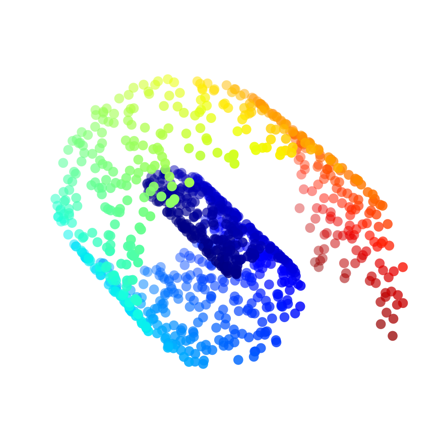

```python
from mpl_toolkits.mplot3d import Axes3D

fig = plt.figure(figsize=(15, 11))
ax = fig.add_subplot(111, projection="3d")

# swiss roll
ax.scatter(
    X[0, :],
    X[1, :],
    X[2, :],
    c=plt.cm.jet((X[0, :] ** 2 + X[2, :] ** 2) / 100),
    s=ms,
    lw=0,
    alpha=1,
)

# params
ax.set_xlim(np.min(X[0, :]), np.max(X[0, :]))
ax.set_ylim(np.min(X[1, :]), np.max(X[1, :]))
ax.set_zlim(np.min(X[2, :]), np.max(X[2, :]))
ax.axis("off")
ax.view_init(elev=el, azim=az)
```

Compute the pairwise Euclidean distance matrix.

```python
from scipy.spatial.distance import cdist

D1 = cdist(X.T, X.T)
```

Number of NN for the graph.

```python
k = 6
```

Compute the k-NN connectivity.

```python
DNN, NN = np.sort(D1), np.argsort(D1)
NN = NN[:, 1 : k + 1]
DNN = DNN[:, 1 : k + 1]
```

Adjacency matrix, and weighted adjacency.

```python
from scipy import sparse

B = np.tile(np.arange(0, n), (k, 1))
A = sparse.coo_matrix((np.ones(k * n), (np.ravel(B, order="F"), np.ravel(NN))))
```

Weighted adjacency (the metric on the graph).

```python
W = sparse.coo_matrix((np.ravel(DNN), (np.ravel(B, order="F"), np.ravel(NN))))
```

Display the graph.

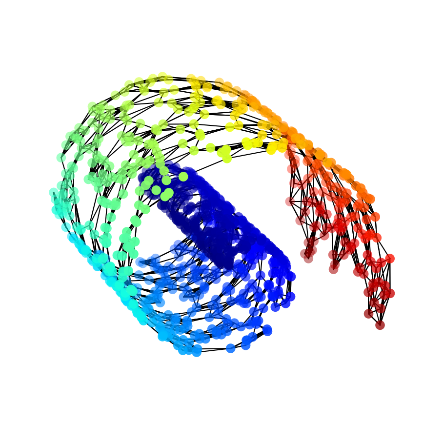

```python
from mpl_toolkits.mplot3d import Axes3D

fig = plt.figure(figsize=(15, 11))
ax = fig.add_subplot(111, projection="3d")

# swiss roll
ax.scatter(
    X[0, :],
    X[1, :],
    X[2, :],
    c=plt.cm.jet((X[0, :] ** 2 + X[2, :] ** 2) / 100),
    s=ms,
    lw=0,
    alpha=1,
)

# graph
I, J, V = sparse.find(A)
xx = np.vstack((X[0, I], X[0, J]))
yy = np.vstack((X[1, I], X[1, J]))
zz = np.vstack((X[2, I], X[2, J]))

for i in range(len(I)):
    ax.plot(xx[:, i], yy[:, i], zz[:, i], color="black")

# params
ax.axis("off")
ax.set_xlim(np.min(X[0, :]), np.max(X[0, :]))
ax.set_ylim(np.min(X[1, :]), np.max(X[1, :]))
ax.set_zlim(np.min(X[2, :]), np.max(X[2, :]))
ax.view_init(elev=el, azim=az)

plt.show()
```

## Floyd Algorithm to Compute Pairwise Geodesic Distances

A simple algorithm to compute the geodesic distances between all pairs of points on a graph is Floyd iterative algorithm. Its complexity is $\mathcal O(n^3)$ where $n$ is the number of points. It is thus quite slow for sparse graph, where Dijkstra runs in $\mathcal O(n^2\log(n))$.

Floyd algorithm iterates the following update rule, for $k=1,\dots,n$

$D(i,j) \leftarrow \min(D(i,j), D(i,k)+D(k,j))$,

with the initialization $D(i,j)=W(i,j)$ if $W(i,j)>0$, and $D(i,j)=Inf$ if $W(i,j)=0$.

Make the graph symmetric.

```python
# An edge is present when either point includes the other among its neighbors.
W = W.tocsr().maximum(W.T.tocsr())
D = W.toarray()
```

Initialize the matrix.

```python
D[D == 0] = float("inf")
```

Add connexion between a point and itself.

```python
np.fill_diagonal(D, 0)
```

**Worked example 1**

```python
from scipy.sparse.csgraph import shortest_path

D = shortest_path(W, directed=False)
if not np.isfinite(D).all():
    raise ValueError("The neighborhood graph is disconnected; increase k.")
assert np.allclose(D, D.T)
```

Find index of vertices that are not connected to the main manifold.

```python
Iremove = np.flatnonzero(~np.isfinite(D[:, 0]))
```

Remove Inf remaining values (disconnected components).

```python
assert np.isfinite(D).all(), "Every pair needs a finite geodesic distance."
```

## Isomap with Classical Multidimensional Scaling

Isomap perform the dimensionality reduction by applying multidimensional scaling.

Please refers to the tours on Bending Invariant for detail on Classical MDS (strain minimization).

**Worked example 2**

Perform classical MDS to compute the 2D flattening.

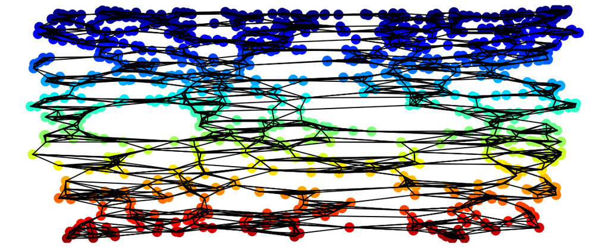

```python
from numpy import linalg

J = np.identity(n) - np.ones([n, n]) / n
K = -1 / 2.0 * np.dot(J, np.dot(D**2, J))

[val, Xstrain] = sparse.linalg.eigsh(K, k=2, which="LA")

Xstrain = Xstrain * np.tile(np.sqrt(np.maximum(val, 0)), (n, 1))
Xstrain = np.real(np.transpose(Xstrain))

# plot size
plt.figure(figsize=(15, 6))

# plot points
plt.scatter(
    Xstrain[0, :],
    Xstrain[1, :],
    ms,
    c=plt.cm.jet((X[0, :] ** 2 + X[2, :] ** 2) / 100),
    lw=0,
    alpha=1,
)

# plot vertices
I, J, V = sparse.find(A)
xx = np.vstack((Xstrain[0, I], Xstrain[0, J]))
yy = np.vstack((Xstrain[1, I], Xstrain[1, J]))

for i in range(len(I)):
    plt.plot(xx[:, i], yy[:, i], color="black")

# params
plt.axis("off")
plt.xlim(np.min(Xstrain[0, :] - 1), np.max(Xstrain[0, :]) + 1)
plt.ylim(np.min(Xstrain[1, :] - 1), np.max(Xstrain[1, :]) + 1)

plt.show()
```

Redess the points using the two leading eigenvectors of the covariance matrix (PCA correction).

```python
[L, U] = linalg.eigh(np.dot(Xstrain, np.transpose(Xstrain)) / n)
Xstrain1 = np.dot(np.transpose(U), Xstrain)
```

Remove problematic points.

```python
Xstrain1[:, Iremove] = float("inf")
```

Display the final result of the dimensionality reduction.

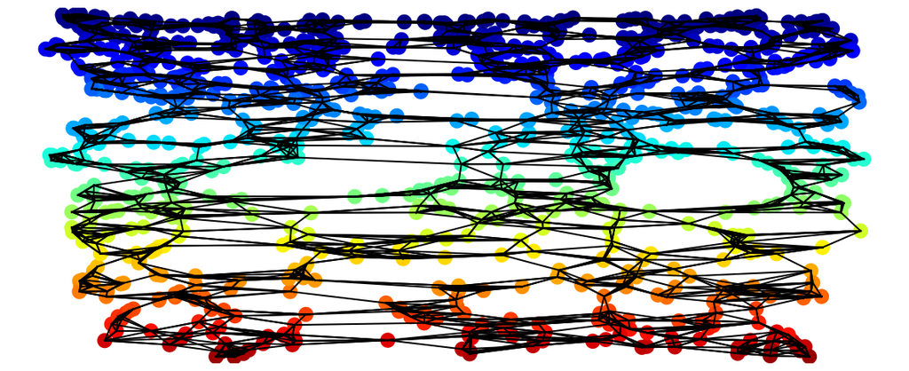

```python
# plot size
plt.figure(figsize=(15, 6))

# plot points
plt.scatter(
    Xstrain1[0, :],
    Xstrain1[1, :],
    ms,
    c=plt.cm.jet((X[0, :] ** 2 + X[2, :] ** 2) / 100),
    lw=0,
    alpha=1,
)

# plot vertices
I, J, V = sparse.find(A)
xx = np.vstack((Xstrain1[0, I], Xstrain1[0, J]))
yy = np.vstack((Xstrain1[1, I], Xstrain1[1, J]))

for i in range(len(I)):
    plt.plot(xx[:, i], yy[:, i], color="black")

# params
plt.axis("off")
plt.xlim(np.min(Xstrain1[0, :] - 1), np.max(Xstrain1[0, :]) + 1)
plt.ylim(np.min(Xstrain1[1, :] - 1), np.max(Xstrain1[1, :]) + 1)

plt.show()
```

For comparison, the ideal locations on the parameter domain.

```python
Y = np.vstack((v, X[1, :]))
Y[0, :] = rescale(Y[0, :], min(Xstrain[0, :]), max(Xstrain[0, :]))
Y[1, :] = rescale(Y[1, :], min(Xstrain[1, :]), max(Xstrain[1, :]))
```

Display the ideal graph on the reduced parameter domain.

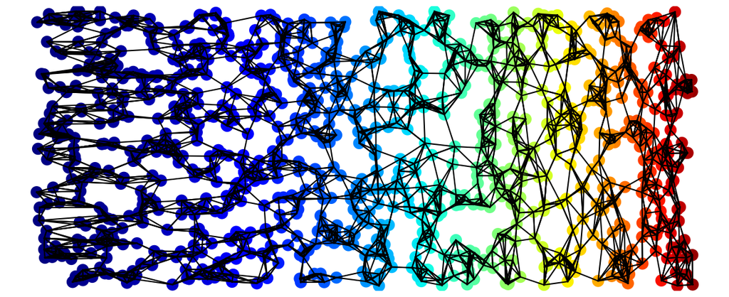

```python
# plot size
plt.figure(figsize=(15, 6))

# plot points
plt.scatter(
    Y[0, :],
    Y[1, :],
    ms,
    c=plt.cm.jet((X[0, :] ** 2 + X[2, :] ** 2) / 100),
    lw=0,
    alpha=1,
)

# plot vertices
I, J, V = sparse.find(A)
xx = np.vstack((Y[0, I], Y[0, J]))
yy = np.vstack((Y[1, I], Y[1, J]))

for i in range(len(I)):
    plt.plot(xx[:, i], yy[:, i], color="black")

# params
plt.axis("off")
plt.xlim(np.min(Y[0, :] - 1), np.max(Y[0, :]) + 1)
plt.ylim(np.min(Y[1, :] - 1), np.max(Y[1, :]) + 1)

plt.show()
```

## Isomap with SMACOF Multidimensional Scaling

It is possible to use SMACOF instead of classical scaling.

Please refers to the tours on Bending Invariant for detail on both Classical MDS (strain minimization) and SMACOF MDS (stress minimization).

**Worked example 3**

Perform stress minimization MDS using SMACOF to compute the 2D flattening.

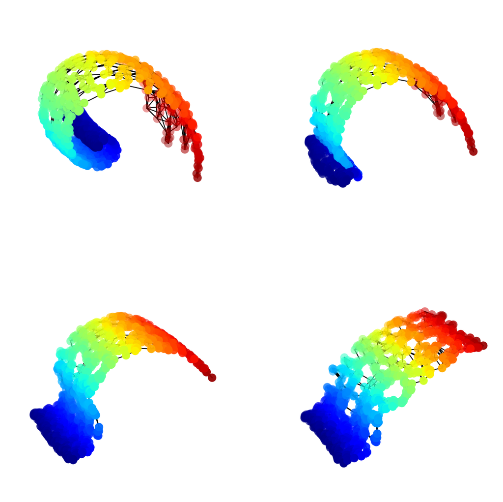

```python
fig = plt.figure(figsize=(15, 15))
niter = 150
stress = []
Xstress = np.copy(X)
ndisp = [1, 5, 10, min(niter, 100), np.inf]
k = 0

for i in range(niter):
    if ndisp[k] == i:
        ax = fig.add_subplot(2, 2, k + 1, projection="3d")

        # swiss roll
        ax.scatter(
            Xstress[0, :],
            Xstress[1, :],
            Xstress[2, :],
            c=plt.cm.jet((X[0, :] ** 2 + X[2, :] ** 2) / 100),
            s=ms,
            lw=0,
            alpha=1,
        )

        # graph
        I, J, V = sparse.find(A)
        xx = np.vstack((Xstress[0, I], Xstress[0, J]))
        yy = np.vstack((Xstress[1, I], Xstress[1, J]))
        zz = np.vstack((Xstress[2, I], Xstress[2, J]))

        for i in range(len(I)):
            ax.plot(xx[:, i], yy[:, i], zz[:, i], color="black")

        # params
        ax.axis("off")
        ax.set_xlim(np.min(Xstress[0, :]), np.max(Xstress[0, :]))
        ax.set_ylim(np.min(Xstress[1, :]), np.max(Xstress[1, :]))
        ax.set_zlim(np.min(Xstress[2, :]), np.max(Xstress[2, :]))
        ax.view_init(elev=el, azim=az)

        k += 1

    # Compute the distance matrix.
    D1 = np.repeat(np.sum(Xstress**2, 0)[:, np.newaxis], n, 1)
    D1 = np.sqrt(
        np.maximum(
            D1 + np.transpose(D1) - 2 * np.dot(np.transpose(Xstress), Xstress), 0
        )
    )

    # Compute the scaling matrix.
    B = -D / np.maximum(D1, 1e-10 * np.ones(np.shape(D1)))
    B = B - np.diag(np.sum(B, 0))

    # update
    Xstress = np.transpose(np.dot(B, np.transpose(Xstress))) / n
    # Xstress = Xstress-repmat(mean(Xstress,2), [1 n]);
    # record stress
    stress = stress + [np.sqrt(np.sum(abs(D - D1) ** 2) / n**2)]

plt.show()
```

Plot stress evolution during minimization.

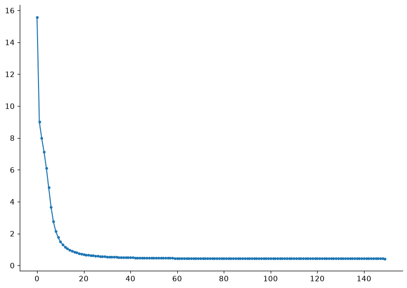

```python
plt.figure(figsize=(10, 7))
plt.plot(stress, ".-")
plt.show()
```

Compute the main direction of the point clouds.

```python
[L, U] = linalg.eigh(np.dot(Xstress, np.transpose(Xstress)) / n)
[L, I] = np.sort(L), np.argsort(L)
U = U[:, I[1:3]]
```

Project the points on the two leading eigenvectors of the covariance matrix (PCA final projection).

```python
Xstress1 = np.dot(np.transpose(U), Xstress)
```

Remove problematic points.

```python
Xstress1[:, Iremove] = np.inf
```

Display the final result of the dimensionality reduction.

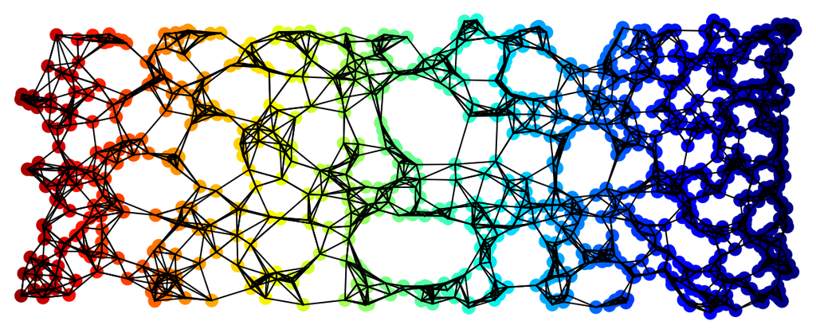

```python
# plot size
plt.figure(figsize=(15, 6))

# plot points
plt.scatter(
    Xstress1[1, :],
    Xstress1[0, :],
    ms,
    c=plt.cm.jet((X[0, :] ** 2 + X[2, :] ** 2) / 100),
    lw=0,
    alpha=1,
)

# plot vertices
I, J, V = sparse.find(A)
xx = np.vstack((Xstress1[1, I], Xstress1[1, J]))
yy = np.vstack((Xstress1[0, I], Xstress1[0, J]))

for i in range(len(I)):
    plt.plot(xx[:, i], yy[:, i], color="black")

# params
plt.axis("off")
plt.xlim(np.min(Xstress1[1, :] - 1), np.max(Xstress1[1, :]) + 1)
plt.ylim(np.min(Xstress1[0, :] - 1), np.max(Xstress1[0, :]) + 1)

plt.show()
```

## References and further reading

- James A. Sethian. [A Fast Marching Level Set Method for Monotonically Advancing Fronts](https://doi.org/10.1073/pnas.93.4.1591). 1996, PNAS 93(4), 1591–1595. A causal numerical solver for the eikonal equation.
- Edsger W. Dijkstra. [A Note on Two Problems in Connexion with Graphs](https://doi.org/10.1007/BF01386390). 1959, Numerische Mathematik 1, 269–271. Shortest paths with nonnegative edge weights.
- Stanley Osher and James A. Sethian. Fronts Propagating with Curvature-Dependent Speed: Algorithms Based on Hamilton–Jacobi Formulations. 1988, Journal of Computational Physics 79(1), 12–49. Implicit front propagation using level-set functions.
- Joshua B. Tenenbaum, Vin de Silva, and John C. Langford. [A Global Geometric Framework for Nonlinear Dimensionality Reduction](https://doi.org/10.1126/science.290.5500.2319). 2000, Science 290, 2319–2323. Geodesic distances and multidimensional scaling for manifold learning.
- Gabriel Peyré. [Advanced Signal, Image and Surface Processing](https://www.numerical-tours.com/book/AdvancedSignalProcessing.pdf). 2010, course notes. A mathematical companion to the Numerical Tours.

**On this page**